# Replication of Study: Transient Spatial Attention Degrades Temporal Resolution by Yeshurun & Levy (2003, Psychological Science)

Insub Kim (insubkim@stanford.edu)

December 09, 2019

## Introduction

Yeshurun and Levy (2003), investigated the effect of spatial attention on visual temporal processes. The authors manipulated observers’ spatial attention by using peripheral pre-cueing and measured their temporal resolution by two-flash fusion threshold (ability to discriminate successive two light flashes). Through this investigation, they found that enhanced spatial attention reduced temporal resolution.

I chose this paper because my research interest lies in establishing a spatial-temporal model for the visual cortex. Specifically, as this paper investigated the relationship between spatial and temporal visual characteristics, replicating this paper would provide further insights on how attentional factors could contribute to interplays between perceptual domain of space and time. In the long run, I would like to incorporate the effect of attention on temporal processing with its emphasis on foveal and peripheral spatial representation differences.

For this project, each observer’s threshold of temporal resolution will be measured in two different conditions (cued and neutral). In cued trials, a periphery cue will be presented before the target onset, which indicates the target’s location. While in neutral trials, neutral cue with no indication of the target’s location will be presented.

The original paper had 3 different experiments. However, I am to only replicate experiment 1 for this project.

- Github repository: https://github.com/psych251/Yeshurun2003
- Original paper: https://github.com/psych251/Yeshurun2003/tree/master/original_paper
- rPubLink: http://rpubs.com/insubkim/558263
- Preregistration: https://osf.io/dmk8n/
- Reference: Yeshurun, Y., & Levy, L. (2003). Transient spatial attention degrades temporal resolution. Psychological Science, 14(3), 225-231.

## Methods

### Power Analysis

Original effect size is not reported in the original paper. Thus, I aim to get 18 participants following the number of participant reported in the original paper.

### Planned Sample

I will use 18 participants.

### Materials

Two-flash fusion threshold: Measure of temporal resolution. “Two flashes of light were presented successively to the same location, and we determined the minimal interval between the flashes at which they were still perceived as two separate flashes, rather than as a single continuous flash. The shorter this critical interval is, the higher the temporal resolution (e.g., Artieda, Pastor, Lacruz, & Obeso, 1992;Reeves, 1996).”

Target: The target (37-cd/m2 disk with a diameter of 3 degrees) was composed of two flashes of light separated by a brief interval or a single continous flash. “It appeared on a black background at one of 11 possible locations along the horizontal meridian, with eccentricity (distance from the center) ranging from 0 to 16.5 degrees. The cue in the cued trials was a 1 X 0.3 degrees green horizontal bar (43 cd/m2) appearing 0.5 degree above the target’s location. In the neutral trials, two 17 x 0.3 degree green horizontal lines appeared above and below the entire display.”

Insturements: 21-inch monitor of a PowerMac G4 computer was used in the original experiment.

### Procedure

Followed the exact procedure as quated from the original article:

“Each trial began with a fixation point followed by the attentional cue. The cue was present until the target’s offset, to prevent confusion between the flickering of the cue and that of the target. The target was presented 94 ms after onset of the cue: On 50% of the trials, two disks appeared, each for 47 ms, separated by a variable interval (interstimulus interval, ISI, of 11–34 ms). On the rest of the trials, a single disk was presented for a duration ranging from 105 to 130 ms. These brief durations ensured that eye movements could not occur between cue onset and target offset (Mayfrank, Kimmig, & Fischer,1987). Each observer viewed 864 trials presented in a randomized order. Both accuracy and reaction time (RT) were recorded.”

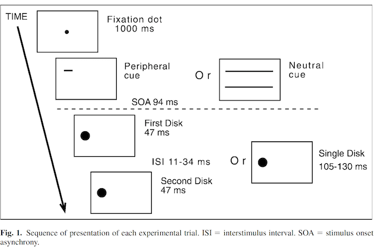

**[Fig.1. adpated from the original paper]**

### Experimetnal Code

Due to the requirement of precise timing of my project, I coded my experiment using MATLAB psychtoolbox.

The link for the exerpeimental code is posted in the github: https://github.com/psych251/Yeshurun2003/tree/master/experiment_code/_STIM

### Analysis Plan

No mention of participant and data exclusion in the origianl paper.

Dependent Variables:

**Key Analysis:**

- Differences between cued and neutral trials
- The effect of interstimulus interval (ISI)

### Differences from Original Study

I tried to minimize all the differences from the original study and there are no specific differences that I can think of from the original.

#### Actual Sample

Although I have planned for 18 participants, I was only able to get 10 participants. The participants were PSYCH 1 students at Stanford.

#### Exclusion

No Data were excluded.

#### Differences from pre-data collection methods plan

Less sample collected (10 participants in total). I was not able to collect 18 participants before the end of the class.

## Results

### Data preparation

Data preparation following the analysis plan.

```r
####Load Relevant Libraries and Functions

library(tidyverse)
library(ggplot2)
library(ggthemes)
library(psycho)
library(ggpubr)
library(gridExtra)
library(cowplot)

####Import data

d <- read_csv("sptioTemporal.csv")

#### Prepare data for analysis - create columns and change variable names

d[d$cue==1,]$cue = 'cued'
d[d$cue==0,]$cue = 'neutral'

x=1:length(unique(d$sub))
new_subNames=sprintf("s0%02d",x)
subNames = unique(d$sub)
for(i in 1:length(subNames)) {
  d$sub[d$sub == subNames[i]] = new_subNames[i]
}


kk = sort(unique(d$targetLoc))
mask1=d$targetLoc ==kk[1]
mask2=d$targetLoc ==kk[2]
mask3=d$targetLoc ==kk[3]
mask4=d$targetLoc ==kk[4]
mask5=d$targetLoc ==kk[5]
mask6=d$targetLoc ==kk[6]

d$targetLoc[mask1] = 0
d$targetLoc[mask2] = 3
d$targetLoc[mask3] = 6
d$targetLoc[mask4] = 9
d$targetLoc[mask5] = 13
d$targetLoc[mask6] = 16


d <- d %>% mutate(
  cue = factor(cue),targetLoc = factor(targetLoc), ISI = factor(ISI)
)
```

```r
#### Compute dPrime

dp <- d %>% group_by(sub,cue,targetLoc,ISI) %>% summarize(nHit = sum(SDT == 'HI' ), nFA = sum(SDT == 'FA' ), nMiss = sum(SDT == 'MI' ), nCR = sum(SDT == 'CR' ), dPrime= dprime(nHit, nFA, nMiss, nCR)$dprime, criterion=dprime(nHit, nFA, nMiss, nCR)$c)

#### Make sub-selection of the data for plotting

dplot_cue <- dp %>% group_by(sub,cue) %>% summarize(dPrime = mean(dPrime))
dplot_ecc <- dp %>% group_by(cue,targetLoc) %>% summarize(dPrime = mean(dPrime))
dplot_ecc2 <- dp %>% group_by(targetLoc,ISI) %>% summarize(dPrime = mean(dPrime))
dplot_ISI <- dp %>% group_by(cue,ISI) %>% summarize(dPrime = mean(dPrime))
dplot_stat_ISI <- dp %>% group_by(sub,cue,ISI) %>% summarize(dPrime = mean(dPrime))


dplot_ecc_sd <- dp %>% group_by(sub,targetLoc,ISI) %>% summarize(dPrime = mean(dPrime))
```

### Confirmatory analysis

The analyses as specified in the analysis plan.

Following the original paper:

“A within-observers three-way analysis of variance (ANOVA; Cuing x Eccentricity x ISI) was performed on the accuracy (d’) and RT data collected on trials with correct responses.”

The key statistic of 3 way ANOVA anova was performed.

```r
# The key statistic: within-subject 3-way Anova
Result <- aov(dPrime ~ (cue*targetLoc*ISI) + Error(sub/cue*targetLoc*ISI), data=dp)

# main effect: Cuing
summary(Result[5])
```

```
##
## Error: sub:cue
##           Df Sum Sq Mean Sq F value Pr(>F)
## cue        1  2.002  2.0023   2.061  0.185
## Residuals  9  8.743  0.9714
```

```r
# interaction effect: Cuing X ISI
summary(Result[10])
```

```
##
## Error: sub:cue:ISI
##           Df Sum Sq Mean Sq F value   Pr(>F)
## cue:ISI    2  7.811   3.905   10.86 0.000806 ***
## Residuals 18  6.474   0.360
## ---
## Signif. codes:  0 '***' 0.001 '**' 0.01 '*' 0.05 '.' 0.1 ' ' 1
```

The original paper found:  
- Significant main effect of cuing: F(1,17)=8.01 p<.01  
- No significant interactions: Cuing X ISI, Cuing X Eccentricity, and ISI X Eccentricity  
- But the performance decrement in the cued trials was more pronounced for shorter ISIs (i.e., when a higher temporal resolution is required) than for longer ISIs and for more central, compared with more peripheral, eccentricities (Figs. 2b–2d, respectively).

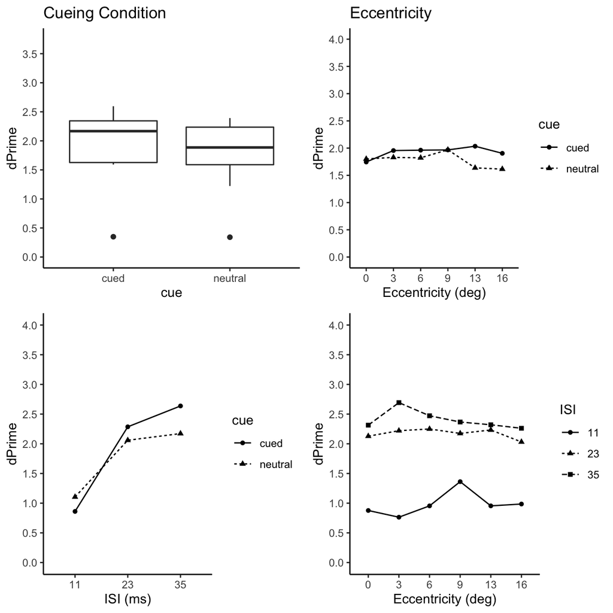

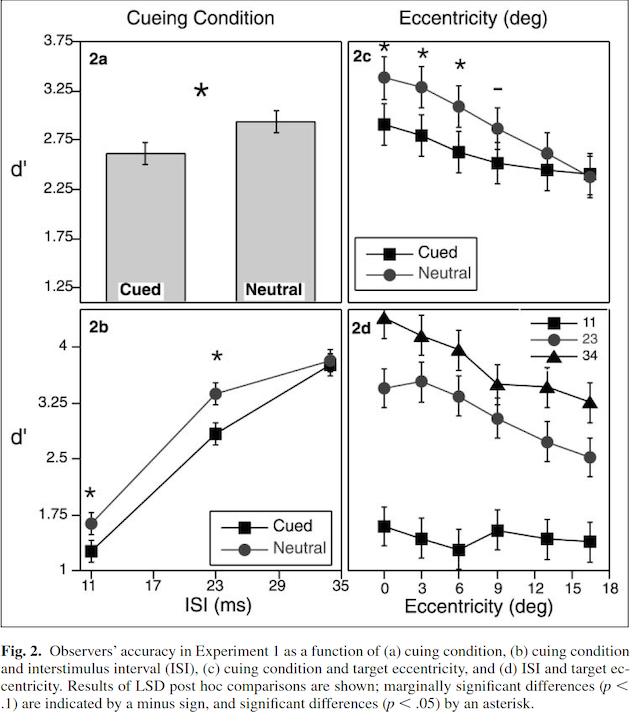

```r
# Cueing effect
p1 <- ggplot(dplot_cue, aes(x=cue, y=dPrime))+
  geom_boxplot() +
  #geom_jitter((aes(colour = sub)), size=3, alpha=0.9) +
  scale_y_continuous(breaks = seq(0,3.75,0.5),limits = c(0,3.75))+
  ggtitle("Cueing Condition") +
  theme_classic()


# Cueing X Ecc
p2 <- ggplot(dplot_ecc, aes(x=targetLoc, y=`dPrime`, group=cue)) +
  geom_line(aes(linetype=cue))+
  geom_point(aes(shape=cue))+
  scale_y_continuous(breaks = seq(0,4,0.5),limits = c(0,4))+
  scale_x_discrete(name="Eccentricity (deg)")+
  ggtitle("Eccentricity") +
  theme_classic()

# Cueing X ISI
p3 <- ggplot(dplot_ISI, aes(x=ISI, y=dPrime, group=cue)) +
  geom_line(aes(linetype=cue))+
  geom_point(aes(shape=cue))+
  scale_y_continuous(breaks = seq(0,4,0.5),limits = c(0,4))+
  scale_x_discrete(name="ISI (ms)")+
  theme_classic()

# ECC X ISI
p4 <- ggplot(dplot_ecc2, aes(x=targetLoc, y=`dPrime`, group=ISI)) +
  geom_line(aes(linetype=ISI))+
  geom_point(aes(shape=ISI))+
  scale_y_continuous(breaks = seq(0,4,0.5),limits = c(0,4))+
  scale_x_discrete(name="Eccentricity (deg)")+
  theme_classic()

plot_grid(p1, p2, p3, p4,ncol = 2, nrow = 2)
```

### Exploratory Analysis

Post-hoc t-test between cueing conditions (cued and neutral) for each ISI (11 ms, 23 ms, 35 ms).

```r
#paired t-test

# ISI == 11
cond1 = filter(dplot_stat_ISI,cue=='cued', ISI == 11)
cond2 = filter(dplot_stat_ISI,cue=='neutral', ISI == 11)
outcome=t.test(cond1$dPrime,cond2$dPrime,paired=TRUE)

pt1 =sprintf("t(%d) = %1.1f, p = %1.3f",outcome$parameter, outcome$statistic,outcome$p.value)
pt1
```

```
## [1] "t(9) = -2.7, p = 0.025"
```

```r
# ISI == 23
cond1 = filter(dplot_stat_ISI, cue=='cued',ISI==23)
cond2 = filter(dplot_stat_ISI,cue=='neutral',ISI==23)
outcome=t.test(cond1$dPrime,cond2$dPrime,paired=TRUE)

pt2 =sprintf("t(%d) = %1.1f, p = %1.3f",outcome$parameter, outcome$statistic,outcome$p.value)
pt2
```

```
## [1] "t(9) = 1.4, p = 0.182"
```

```r
# ISI == 35
cond1 = filter(dplot_stat_ISI, cue=='cued',ISI==35)
cond2 = filter(dplot_stat_ISI,cue=='neutral',ISI==35)
outcome=t.test(cond1$dPrime,cond2$dPrime,paired=TRUE)

pt3 =sprintf("t(%d) = %1.1f, p = %1.3f",outcome$parameter, outcome$statistic,outcome$p.value)
pt3
```

```
## [1] "t(9) = 3.0, p = 0.014"
```

## Discussion

### Summary of Replication Attempt

1. No main effect of cueing.

Although the original paper reported the main effect of cueing. The current paper found no differences between cueing and neutral condtions.

2. Interaction effect of cueing and ISI